# EcoFlux_FinalProject

## **EcoFlux: A Machine Learning Energy Consumption Estimator**

```
      Making machine learning greener through transparency
```

**Team Members**:  
Sabrina Ronnie George Karippatt - 8991911  
Jiho Jun - 9080800  
Edwin Lopez - 9055061  
Andrew Silveira - 5077086

**Course:** *Foundations of Machine Learning Frameworks*

**Presentation Date:** 12-Dec-2025

### **Dataset Creation & Methodology**

In this section we generate a synthetic dataset for **EcoFlux**, a machine learning energy consumption estimator. The dataset encodes a simple, transparent relationship between three input features:

- `num_layers` – number of layers in the model
- `training_hours` – total training time in hours
- `flops_per_hour` – approximate compute intensity in GFLOPs/hour

and a continuous target:

- `energy_kwh` – approximate total energy usage in kWh

The goal is to create a small, reproducible dataset that captures the expected trends between model complexity, training time, and energy consumption.

```python
#Import necessary libraries
import numpy as np
import pandas as pd
from pathlib import Path
import matplotlib.pyplot as plt
import seaborn as sns
from sklearn.preprocessing import StandardScaler
from sklearn.neural_network import MLPRegressor
import os
import joblib

# Model Development
# scikit-learn tools for splitting, modeling, and evaluation
from sklearn.model_selection import train_test_split
from sklearn.linear_model import LinearRegression
from sklearn.metrics import mean_absolute_error, mean_squared_error, r2_score
from sklearn.ensemble import RandomForestRegressor
from sklearn.ensemble import IsolationForest
from sentence_transformers import SentenceTransformer
from sklearn.metrics.pairwise import cosine_similarity
import re

sns.set(style="whitegrid")
```

#### **Create Synthetic Dataset**

In this cell we create a small *synthetic* dataset that simulates how training energy might scale with model and compute settings.

```python
# --- EcoFlux synthetic dataset generation (Updated to 100 rows) --- #

# rng = np.random.default_rng(42)  # reproducible seed

# n_rows = 120   # Updated from 60 → 100 to match the final project structure

# # Feature sampling
# num_layers = rng.integers(2, 25, size=n_rows)           # 2–24 layers
# training_hours = rng.uniform(0.5, 24.0, size=n_rows)    # training duration
# flops_per_hour = rng.uniform(10.0, 300.0, size=n_rows)  # GFLOPs/hour

# # Underlying "true" energy model with added noise
# base = 0.5
# energy_kwh = (
#     base
#     + 0.05 * num_layers
#     + 0.02 * training_hours * (flops_per_hour / 50.0)
#     + rng.normal(0, 0.8, size=n_rows)  # Gaussian noise
# )

# # Clip to non-negative values
# energy_kwh = np.clip(energy_kwh, a_min=0.2, a_max=None)

# # Create DataFrame
# df = pd.DataFrame({
#     "num_layers": num_layers,
#     "training_hours": training_hours.round(2),
#     "flops_per_hour": flops_per_hour.round(1),
#     "energy_kwh": energy_kwh.round(2),
# })

# display(df.head())

# # Save to ../data
# data_dir = Path("..") / "data"
# data_dir.mkdir(parents=True, exist_ok=True)
# csv_path = data_dir / "energy_synthetic.csv"
# df.to_csv(csv_path, index=False)

# print(f"Saved synthetic dataset to: {csv_path.resolve()}")
# print("Shape:", df.shape)
```

#### **Structured Synthetic Dataset**

- To simulate the energy consumption of AI model training
- Enforces physical relationships between the input features and the target

```python
# 1. Load the original dataset to understand the feature ranges
# (Assuming the file exists; if not, the code generates new data from scratch based on defined ranges)
try:
    df_original = pd.read_csv('../data/energy_synthetic.csv')
    print("Original file loaded successfully.")

except FileNotFoundError:
    print("Original file not found. Proceeding with synthetic generation based on default ranges.")
    print(f"Current working directory: {os.getcwd()}")

# 2. Initialize a new DataFrame for synthetic data generation (Augment to 1000 samples)
n_samples = 1000
np.random.seed(42)  # Fix random seed for reproducibility

data = {
    'num_layers': np.random.randint(4, 50, n_samples),           # Number of layers: Range 4 to 50
    'training_hours': np.random.uniform(0.5, 48.0, n_samples),   # Training duration: 0.5 to 48 hours
    'flops_per_hour': np.random.uniform(10.0, 500.0, n_samples)  # Compute intensity: 10 to 500 TFLOPS
}

df_new = pd.DataFrame(data)

# 3. Define Target Logic (Energy Consumption) - Enforcing Physical Relationships
# Formula: Energy ~ (Constant * Layers * Hours * FLOPs) + (Linear Factor * Hours) + Noise
# Rationale: Energy consumption scales with model complexity (layers), duration, and compute intensity.

# Scaling factor to adjust values to realistic kWh units
C = 0.00005

# Calculate base energy using interaction terms (Strong non-linear correlation)
true_energy = (
    C * df_new['num_layers'] * df_new['training_hours'] * df_new['flops_per_hour'] +  # Main interaction term
    0.01 * df_new['training_hours'] * df_new['num_layers']                            # Secondary linear dependency
)

# Add Gaussian noise for realism (Real-world data is rarely perfect)
# Noise level is set to 10% of the mean energy
noise = np.random.normal(0, 0.1 * true_energy.mean(), n_samples)
df_new['energy_kwh'] = true_energy + noise

# Ensure no negative energy values (Energy cannot be negative)
df_new['energy_kwh'] = df_new['energy_kwh'].apply(lambda x: max(x, 0.1))

# 4. Save the generated structured dataset
output_dir = '../data'
output_filename = os.path.join(output_dir, 'energy_synthetic_structured.csv')

# Check if file already exists
if os.path.exists(output_filename):
    print(f"File '{output_filename}' already exists. Skipping save to avoid overwriting.")
else:
    if not os.path.exists(output_dir):
        os.makedirs(output_dir)

    df_new.to_csv(output_filename, index=False)
    print(f"New structured dataset saved as '{output_filename}'.")
```

```
Original file loaded successfully.
File '../data\energy_synthetic_structured.csv' already exists. Skipping save to avoid overwriting.
```

**Dataset Generation Summary**

- `num_layers` — model depth
- `training_hours` — duration of training
- `flops_per_hour` — compute intensity
- `energy_kwh` — estimated energy consumption (target)

- ../data/energy_synthetic.csv

**Based on this Random generated Dataset, Add relation**

This dataset is fully reproducible, noise-aware, and designed specifically for training and evaluating the EcoFlux regression models.

#### Data Visualzie

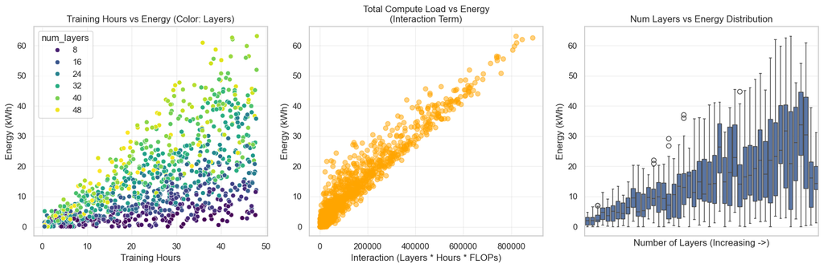

```python
# Visualize Data Relationships
plt.figure(figsize=(15, 5))

# Plot 1: Training Hours vs Energy (Color-coded by Number of Layers)
plt.subplot(1, 3, 1)
sns.scatterplot(data=df_new, x='training_hours', y='energy_kwh', hue='num_layers', palette='viridis')
plt.title('Training Hours vs Energy (Color: Layers)')
plt.xlabel('Training Hours')
plt.ylabel('Energy (kWh)')
plt.grid(True, alpha=0.3)

# Plot 2: Total Compute Load (Layers * Hours * FLOPs) vs Energy
# This should show a strong linear relationship, ideal for MLP training.
plt.subplot(1, 3, 2)
interaction_term = df_new['num_layers'] * df_new['training_hours'] * df_new['flops_per_hour']
plt.scatter(interaction_term, df_new['energy_kwh'], alpha=0.5, color='orange')
plt.title('Total Compute Load vs Energy\n(Interaction Term)')
plt.xlabel('Interaction (Layers * Hours * FLOPs)')
plt.ylabel('Energy (kWh)')
plt.grid(True, alpha=0.3)

# Plot 3: Number of Layers vs Energy Distribution
plt.subplot(1, 3, 3)
sns.boxplot(data=df_new, x='num_layers', y='energy_kwh')
plt.title('Num Layers vs Energy Distribution')
plt.xticks([])  # Hide x-axis labels for cleaner visualization due to many categories
plt.xlabel('Number of Layers (Increasing ->)')
plt.ylabel('Energy (kWh)')
plt.grid(True, alpha=0.3)

plt.tight_layout()
plt.show()
```

### **Basic Dataset Validation**

Before proceeding to exploratory analysis or model training, we perform simple sanity checks to ensure the synthetic dataset was generated correctly.  
This includes:

- confirming column data types
- checking statistical ranges
- verifying that no missing values exist

These checks help ensure the EcoFlux modeling pipeline begins with a clean, reliable dataset.

```python
# Basic sanity checks
print(df_new.info())
display(df_new.describe())

print("\nMissing values per column:")
print(df_new.isna().sum())
```

```
<class 'pandas.core.frame.DataFrame'>
RangeIndex: 1000 entries, 0 to 999
Data columns (total 4 columns):
 #   Column          Non-Null Count  Dtype
---  ------          --------------  -----
 0   num_layers      1000 non-null   int32
 1   training_hours  1000 non-null   float64
 2   flops_per_hour  1000 non-null   float64
 3   energy_kwh      1000 non-null   float64
dtypes: float64(3), int32(1)
memory usage: 27.5 KB
None
```

|  | num_layers | training_hours | flops_per_hour | energy_kwh |
| --- | --- | --- | --- | --- |
| count | 1000.000000 | 1000.000000 | 1000.000000 | 1000.000000 |
| mean | 26.289000 | 24.513234 | 254.100779 | 14.880199 |
| std | 13.139487 | 13.408475 | 143.039835 | 13.101327 |
| min | 4.000000 | 0.511282 | 10.092316 | 0.100000 |
| 25% | 15.000000 | 12.846233 | 125.121223 | 4.584791 |
| 50% | 27.000000 | 25.271979 | 258.551880 | 11.111463 |
| 75% | 38.000000 | 35.988423 | 377.181086 | 21.630053 |
| max | 49.000000 | 47.969291 | 499.859764 | 63.151302 |

```
Missing values per column:
num_layers        0
training_hours    0
flops_per_hour    0
energy_kwh        0
dtype: int64
```

**Validation Summary**

The sanity-check results confirm that the EcoFlux dataset is valid:

- All 1000 rows are present with no missing values
- Data types are correct (`int` for layers, `float` for all others)
- Summary statistics show realistic and diverse values across all features

With the dataset confirmed to be clean and correctly structured, we can now move to **Exploratory Data Analysis (EDA)** to understand patterns and relationships before building the regression models.

### **Exploratory Data Analysis (EDA)**

To better understand the structure of the EcoFlux synthetic dataset, this section visualizes the distributions of all variables, examines relationships between inputs and the target (`energy_kwh`), and inspects correlations. These plots help confirm that the dataset behaves as expected and provide intuition for how each feature contributes to energy consumption.

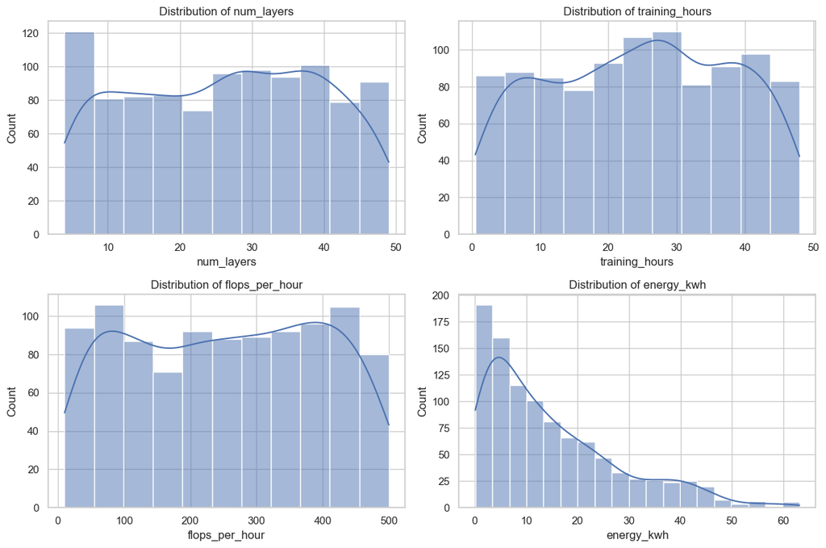

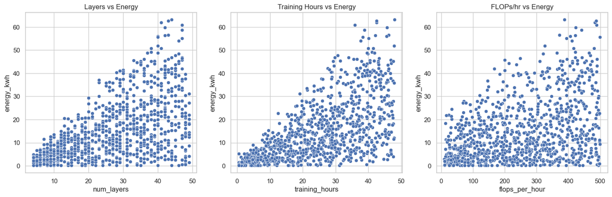

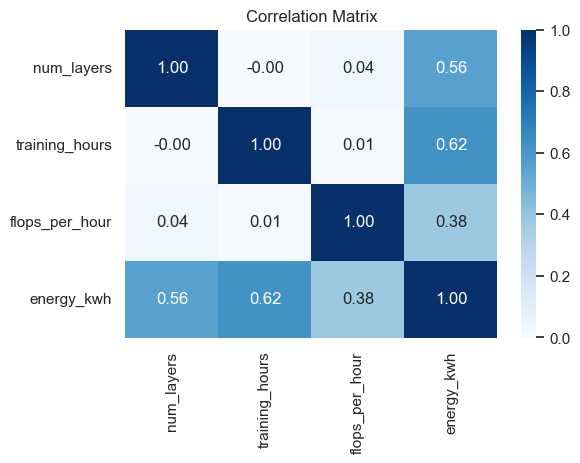

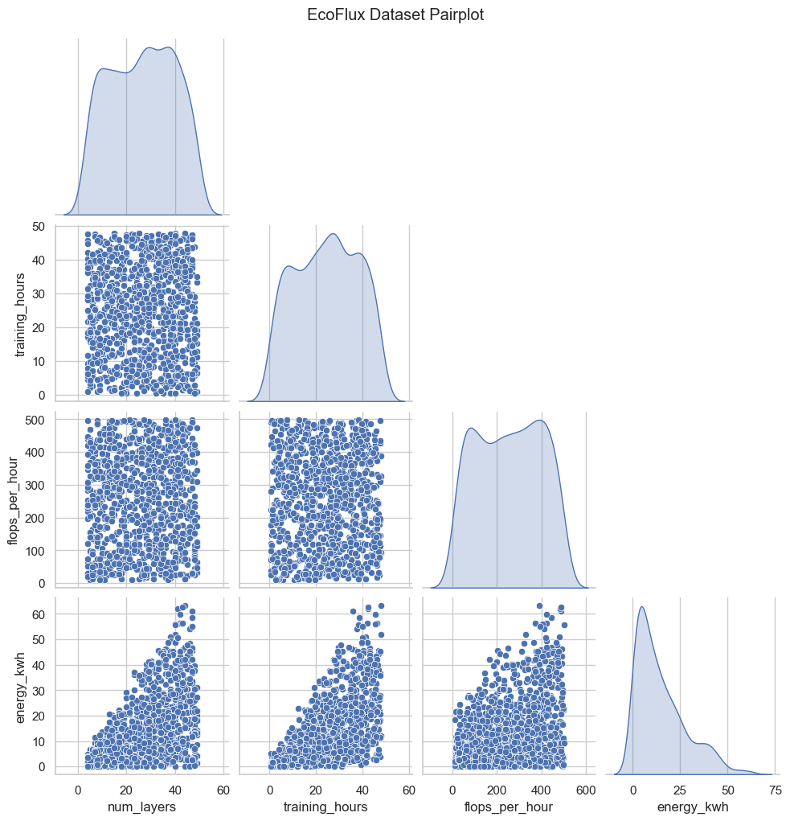

```python
# 1. Distribution Plots (Histograms)
fig, axes = plt.subplots(2, 2, figsize=(12, 8))

columns = ["num_layers", "training_hours", "flops_per_hour", "energy_kwh"]

for ax, col in zip(axes.flatten(), columns):
    sns.histplot(df_new[col], kde=True, ax=ax)
    ax.set_title(f"Distribution of {col}")

plt.tight_layout()
plt.show()


# 2. Scatter Plots vs Target
fig, axes = plt.subplots(1, 3, figsize=(18, 5))

sns.scatterplot(x="num_layers", y="energy_kwh", data=df_new, ax=axes[0])
sns.scatterplot(x="training_hours", y="energy_kwh", data=df_new, ax=axes[1])
sns.scatterplot(x="flops_per_hour", y="energy_kwh", data=df_new, ax=axes[2])

axes[0].set_title("Layers vs Energy")
axes[1].set_title("Training Hours vs Energy")
axes[2].set_title("FLOPs/hr vs Energy")

plt.show()


# 3. Correlation Heatmap

plt.figure(figsize=(6, 4))
corr = df_new.corr(numeric_only=True)

sns.heatmap(corr, annot=True, cmap="Blues", fmt=".2f")
plt.title("Correlation Matrix")
plt.show()


# 4. Pairplot (Corner=True)

sns.pairplot(df_new, diag_kind="kde", corner=True)
plt.suptitle("EcoFlux Dataset Pairplot", y=1.02)
plt.show()
```

**EDA Summary**

The visual analysis provides several important insights:

**• Feature distributions:**  
All four variables show smooth, realistic spreads with no missing values or unexpected spikes. This confirms the synthetic sampling behaved correctly.

**• Scatter plots:**  
Clear upward trends appear between all three input features and energy usage. This matches the synthetic formula: deeper models, longer training, and higher compute intensity all increase `energy_kwh`.

**• Correlation matrix:**  
Moderate positive correlations are visible between each feature and `energy_kwh`, with no signs of multicollinearity. This indicates that both linear and nonlinear regressors should perform well.

With the dataset fully validated and explored, we can now proceed to **Model Development**, where EcoFlux will learn to predict energy consumption based on model architecture and compute characteristics.

### **Model Development**

In this section, EcoFlux learns to predict `energy_kwh` from the three input features:

- `num_layers`
- `training_hours`
- `flops_per_hour`

We build and compare three regression models:

1. A baseline **Linear Regression** model
2. A small **MLPRegressor** (neural network) with standardized inputs
3. **Random forest** model

#### **Part 1: Linear Regression**

In this step, we begin the model development phase by training a simple Linear Regression model on the EcoFlux dataset. We will:

- select the features (X) and target (y)
- split the data into training/testing sets
- fit a Linear Regression model
- evaluate its performance using MAE, MSE, RMSE, and R²

This serves as our baseline model before introducing the neural network version.

```python
# Define features (X) and target (y)
# X contains the three independent variables
X = df_new[["num_layers", "training_hours", "flops_per_hour"]].values

# y contains the continuous energy target
y = df_new["energy_kwh"].values
y_min = df_new["energy_kwh"].min()

# Train/Test split
# Reserve 25% of data for testing.
# random_state makes the split reproducible.
X_train, X_test, y_train, y_test = train_test_split(
    X, y, test_size=0.25, random_state=1911
)

print("Train shape:", X_train.shape, " Test shape:", X_test.shape)

# Baseline Model: Linear Regression
# Create the linear model
lin_reg = LinearRegression()

# Fit the model on the training data
lin_reg.fit(X_train, y_train)

# Predictions on train and test sets
y_train_pred_lin = lin_reg.predict(X_train)
y_test_pred_lin = lin_reg.predict(X_test)

# Helper function for metrics
def regression_metrics(y_true, y_pred):
    """Compute MAE, MSE, RMSE, and R² for regression performance."""
    mae = mean_absolute_error(y_true, y_pred)
    mse = mean_squared_error(y_true, y_pred)
    rmse = np.sqrt(mse)
    r2 = r2_score(y_true, y_pred)
    return mae, mse, rmse, r2

# Evaluate linear regression performance
lin_mae, lin_mse, lin_rmse, lin_r2 = regression_metrics(y_test, y_test_pred_lin)

print("\nLinear Regression (Test Set Results):")
print(f"  MAE  : {lin_mae:.3f}")
print(f"  MSE  : {lin_mse:.3f}")
print(f"  RMSE : {lin_rmse:.3f}")
print(f"  R²   : {lin_r2:.3f}")


print("coef:", lin_reg.coef_)
print("intercept:", lin_reg.intercept_)
```

```
Train shape: (750, 3)  Test shape: (250, 3)

Linear Regression (Test Set Results):
  MAE  : 4.278
  MSE  : 30.317
  RMSE : 5.506
  R²   : 0.796
coef: [0.5470537  0.61679708 0.03297245]
intercept: -22.826960637773958
```

**Summary**

The baseline Linear Regression model was successfully trained and evaluated.

Key observations from the test-set performance:

- MAE: 4.278
- RMSE: 5.506 → typical prediction error magnitude
- R²: 0.796 → the model explains ~80% of the variance in energy consumption

This gives us a reasonable starting point, but also shows that energy usage is not fully linear, which justifies exploring a more flexible model next — the MLPRegressor.

#### **Part 2: MLPRegressor (Neural Network)**

To complement the linear baseline, we train a small neural network using `MLPRegressor`. Unlike linear regression, neural networks can capture non-linear relationships, but they require standardized inputs to perform well.

In this step, we:

- Standardize the training and test features
- Define a two-layer neural network
- Train it on the scaled data
- Evaluate its performance on the test set
- Compare it directly against the linear model

This helps determine whether additional model complexity provides meaningful gains on our synthetic EcoFlux dataset.

```python
# Scale the features for neural network
# Neural nets learn better when features are standardized
scaler = StandardScaler()

# Fit scaler on training data only, then transform both sets
X_train_scaled = scaler.fit_transform(X_train)
X_test_scaled = scaler.transform(X_test)

# 5.5 Define and train the MLPRegressor

mlp = MLPRegressor(
    hidden_layer_sizes=(32, 16),   # two hidden layers
    activation="relu",
    solver="adam",
    max_iter=2000,                 # ensure convergence
    random_state=1911
)

# Train the neural model
mlp.fit(X_train_scaled, y_train)

# Predictions with the MLP model
y_train_pred_mlp = mlp.predict(X_train_scaled)
y_test_pred_mlp = mlp.predict(X_test_scaled)

# Evaluate the MLPRegressor
mlp_mae, mlp_mse, mlp_rmse, mlp_r2 = regression_metrics(y_test, y_test_pred_mlp)

print("\nMLPRegressor (Test Set Results):")
print(f"  MAE  : {mlp_mae:.3f}")
print(f"  MSE  : {mlp_mse:.3f}")
print(f"  RMSE : {mlp_rmse:.3f}")
print(f"  R²   : {mlp_r2:.3f}")

# Compare models side by side

results_df = pd.DataFrame({
    "model": ["Linear Regression", "MLPRegressor"],
    "MAE":   [lin_mae, mlp_mae],
    "MSE":   [lin_mse, mlp_mse],
    "RMSE":  [lin_rmse, mlp_rmse],
    "R2":    [lin_r2, mlp_r2],
})

display(results_df)
```

```
MLPRegressor (Test Set Results):
  MAE  : 1.218
  MSE  : 2.401
  RMSE : 1.550
  R²   : 0.984
```

|  | model | MAE | MSE | RMSE | R2 |
| --- | --- | --- | --- | --- | --- |
| 0 | Linear Regression | 4.278461 | 30.316749 | 5.506065 | 0.796290 |
| 1 | MLPRegressor | 1.218188 | 2.401271 | 1.549603 | 0.983865 |

**MLPRegressor Results Summary**

Next, both models will be saved and integrated into the EcoFlux Streamlit GUI to provide real-time energy predictions.

#### **Part 3: RandomForest Regression**

To compare with Linear regression & MLP, create one more model

```python
# 1) Define the Random Forest Regressor
rf = RandomForestRegressor(
    n_estimators=300,      # number of trees in the forest
    max_depth=None,       # let trees grow until pure or min_samples limits
    min_samples_leaf=1,   # minimum samples per leaf node
    random_state=1911,    # for reproducibility
    n_jobs=-1             # use all available CPU cores
)

# 2) Fit the model on the original (unscaled) training data
rf.fit(X_train, y_train)

# 3) Predictions on train and test sets
y_train_pred_rf = rf.predict(X_train)
y_test_pred_rf = rf.predict(X_test)

# 4) Evaluate RF performance on the test set
rf_mae, rf_mse, rf_rmse, rf_r2 = regression_metrics(y_test, y_test_pred_rf)

print("\nRandomForestRegressor (Test Set Results):")
print(f"  MAE  : {rf_mae:.3f}")
print(f"  MSE  : {rf_mse:.3f}")
print(f"  RMSE : {rf_rmse:.3f}")
print(f"  R²   : {rf_r2:.3f}")

# Linear Regression
lin_train_mae, lin_train_mse, lin_train_rmse, lin_train_r2 = regression_metrics(
    y_train, y_train_pred_lin
)

# MLPRegressor
mlp_train_mae, mlp_train_mse, mlp_train_rmse, mlp_train_r2 = regression_metrics(
    y_train, y_train_pred_mlp
)

# RandomForestRegressor
rf_train_mae, rf_train_mse, rf_train_rmse, rf_train_r2 = regression_metrics(
    y_train, y_train_pred_rf
)

results_train_df = pd.DataFrame({
    "model": ["Linear Regression", "MLPRegressor", "RandomForestRegressor"],
    "MAE":   [lin_train_mae,  mlp_train_mae,  rf_train_mae],
    "RMSE":  [lin_train_rmse, mlp_train_rmse, rf_train_rmse],
    "R2":    [lin_train_r2,   mlp_train_r2,   rf_train_r2],
})

# Separate test performance table
results_test_df = pd.DataFrame({
    "model": ["Linear Regression", "MLPRegressor", "RandomForestRegressor"],
    "MAE":   [lin_mae,        mlp_mae,        rf_mae],
    "RMSE":  [lin_rmse,       mlp_rmse,       rf_rmse],
    "R2":    [lin_r2,         mlp_r2,         rf_r2],
})

print("\n=== Train set performance ===")
print(results_train_df)

print("\n=== Test set performance ===")
print(results_test_df)
```

```
RandomForestRegressor (Test Set Results):
  MAE  : 1.633
  MSE  : 4.496
  RMSE : 2.120
  R²   : 0.970

=== Train set performance ===
                   model       MAE      RMSE        R2
0      Linear Regression  4.091916  5.533919  0.828932
1           MLPRegressor  1.062372  1.348142  0.989847
2  RandomForestRegressor  0.584013  0.768923  0.996697

=== Test set performance ===
                   model       MAE      RMSE        R2
0      Linear Regression  4.278461  5.506065  0.796290
1           MLPRegressor  1.218188  1.549603  0.983865
2  RandomForestRegressor  1.632975  2.120265  0.969793
```

**Result analysis**

- MLP and Random Forest regression both showed strong performance, but the MLP performed slightly better on the test set

> For comparison, we focus on comparing the Linear Regression model with the MLP regression model

## Visualization & Compare

```
Model performance comparison (test set):
               model       MAE        MSE      RMSE        R2
0  Linear Regression  4.278461  30.316749  5.506065  0.796290
1       MLPRegressor  1.218188   2.401271  1.549603  0.983865
```

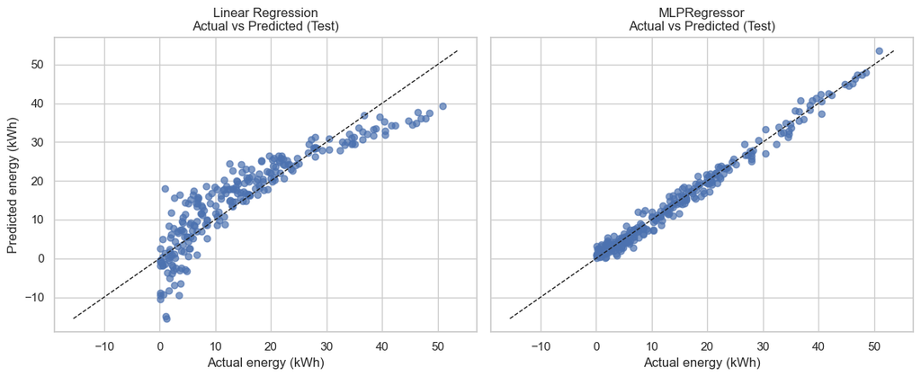

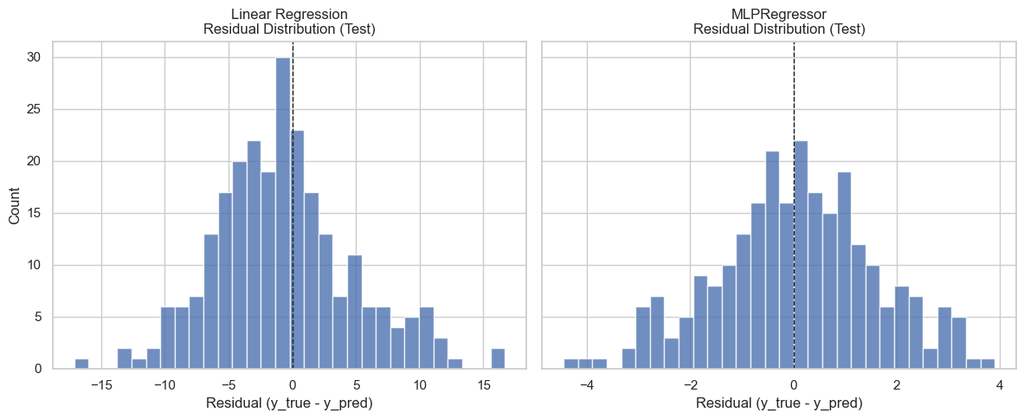

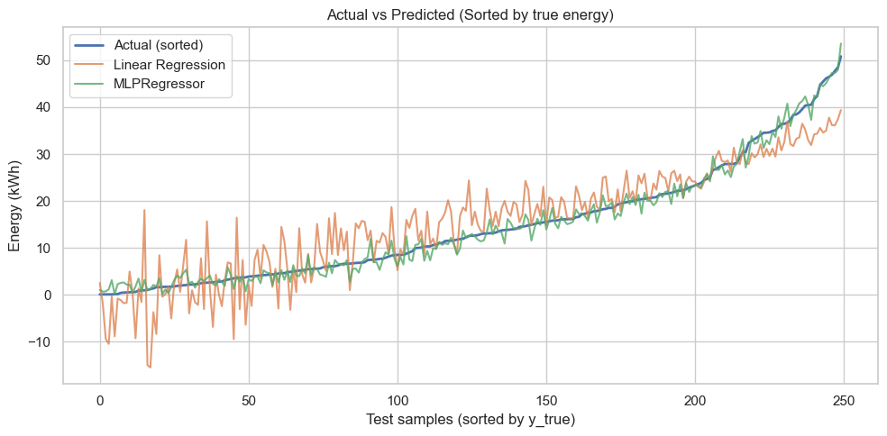

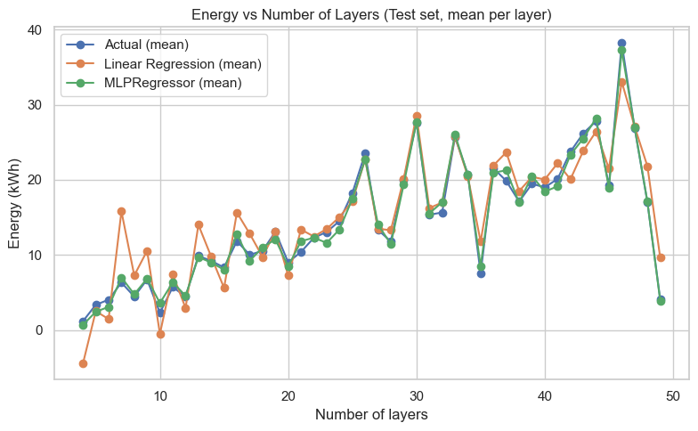

```python
# 1) Print / display performance table

print("\nModel performance comparison (test set):")
print(results_df)


# 2) Actual vs Predicted scatter plots

# Make sure we have numpy arrays
y_test_np = np.array(y_test)
y_pred_lin_np = np.array(y_test_pred_lin)
y_pred_mlp_np = np.array(y_test_pred_mlp)

min_val = min(y_test_np.min(), y_pred_lin_np.min(), y_pred_mlp_np.min())
max_val = max(y_test_np.max(), y_pred_lin_np.max(), y_pred_mlp_np.max())

fig, axes = plt.subplots(1, 2, figsize=(12, 5), sharex=True, sharey=True)

# ---- Left: Linear Regression ----
ax = axes[0]
ax.scatter(y_test_np, y_pred_lin_np, alpha=0.7)
ax.plot([min_val, max_val], [min_val, max_val], "k--", linewidth=1)
ax.set_title("Linear Regression\nActual vs Predicted (Test)")
ax.set_xlabel("Actual energy (kWh)")
ax.set_ylabel("Predicted energy (kWh)")
ax.grid(True)

# ---- Right: MLPRegressor ----
ax = axes[1]
ax.scatter(y_test_np, y_pred_mlp_np, alpha=0.7)
ax.plot([min_val, max_val], [min_val, max_val], "k--", linewidth=1)
ax.set_title("MLPRegressor\nActual vs Predicted (Test)")
ax.set_xlabel("Actual energy (kWh)")
ax.grid(True)

plt.tight_layout()
plt.show()

# 3) Residual distribution comparison

res_lin = y_test_np - y_pred_lin_np
res_mlp = y_test_np - y_pred_mlp_np

fig, axes = plt.subplots(1, 2, figsize=(12, 5), sharey=True)

# ---- Left: Linear residuals ----
ax = axes[0]
ax.hist(res_lin, bins=30, alpha=0.8)
ax.axvline(0, color="k", linestyle="--", linewidth=1)
ax.set_title("Linear Regression\nResidual Distribution (Test)")
ax.set_xlabel("Residual (y_true - y_pred)")
ax.set_ylabel("Count")
ax.grid(True)

# ---- Right: MLP residuals ----
ax = axes[1]
ax.hist(res_mlp, bins=30, alpha=0.8)
ax.axvline(0, color="k", linestyle="--", linewidth=1)
ax.set_title("MLPRegressor\nResidual Distribution (Test)")
ax.set_xlabel("Residual (y_true - y_pred)")
ax.grid(True)

plt.tight_layout()
plt.show()

# 4) sorted predictions line plot

# Sort by true target for a clearer comparison
sort_idx = np.argsort(y_test_np)
y_true_sorted = y_test_np[sort_idx]
y_lin_sorted = y_pred_lin_np[sort_idx]
y_mlp_sorted = y_pred_mlp_np[sort_idx]

plt.figure(figsize=(10, 5))
plt.plot(y_true_sorted, label="Actual (sorted)", linewidth=2)
plt.plot(y_lin_sorted, label="Linear Regression", alpha=0.8)
plt.plot(y_mlp_sorted, label="MLPRegressor", alpha=0.8)
plt.title("Actual vs Predicted (Sorted by true energy)")
plt.xlabel("Test samples (sorted by y_true)")
plt.ylabel("Energy (kWh)")
plt.legend()
plt.grid(True)
plt.tight_layout()
plt.show()


# 5) layer predictions line plot

# 1. Extract the number of layers for each test sample
#    Assuming the first column of X_test corresponds to num_layers.
layers_test = X_test[:, 0]

# 2. Build a DataFrame combining layers and predictions
df_layer_vis = pd.DataFrame({
    "num_layers": layers_test,
    "y_true": y_test,               # actual energy (kWh)
    "y_pred_lin": y_test_pred_lin,  # linear regression predictions
    "y_pred_mlp": y_test_pred_mlp,  # MLPRegressor predictions
})

# 3. Aggregate by num_layers to compute the mean energy per layer count
df_layer_mean = (
    df_layer_vis
    .groupby("num_layers")
    .mean(numeric_only=True)
    .reset_index()
    .sort_values("num_layers")
)

# 4. Plot mean Actual / Linear / MLP energy as a function of num_layers
plt.figure(figsize=(8, 5))

plt.plot(
    df_layer_mean["num_layers"],
    df_layer_mean["y_true"],
    marker="o",
    label="Actual (mean)",
)
plt.plot(
    df_layer_mean["num_layers"],
    df_layer_mean["y_pred_lin"],
    marker="o",
    label="Linear Regression (mean)",
)
plt.plot(
    df_layer_mean["num_layers"],
    df_layer_mean["y_pred_mlp"],
    marker="o",
    label="MLPRegressor (mean)",
)

plt.title("Energy vs Number of Layers (Test set, mean per layer)")
plt.xlabel("Number of layers")
plt.ylabel("Energy (kWh)")
plt.legend()
plt.grid(True)
plt.tight_layout()
plt.show()
```

- Both the error metrics and the visual inspection show that the MLP achieves better predictive performance than linear regression.
- In the case of linear regression, the residual distribution tends to be skewed to the left around the center, indicating higher variability for smaller values.
- For the MLP, since the inputs are standardized, the residuals are more evenly distributed.

### **Saving Trained Models for Deployment**

To integrate EcoFlux into a Streamlit-based user interface, both trained models must be saved to disk so they can be loaded later for real-time predictions.

In this step, we:

- Create a `/models` directory (if it does not exist)
- Save the **Linear Regression** model as a standalone `.pkl` file
- Save the **MLPRegressor** model **together with its StandardScaler** in one bundle  
  (ensuring consistent preprocessing during GUI inference)

These files will be accessed by the EcoFlux application during the prediction phase.

```python
# Save trained models (for Streamlit GUI)

models_dir = Path("..") / "models"
models_dir.mkdir(parents=True, exist_ok=True)

# Save linear model
lin_path = models_dir / "ecoflux_linear_regression.pkl"
joblib.dump(lin_reg, lin_path)

# Save MLPRegressor + scaler together
mlp_bundle = {
    "scaler": scaler,
    "model": mlp
}

mlp_path = models_dir / "ecoflux_mlp_regressor.pkl"
joblib.dump(mlp_bundle, mlp_path)

print(f"Saved Linear Regression to: {lin_path.resolve()}")
print(f"Saved MLPRegressor (with scaler) to: {mlp_path.resolve()}")
```

```
Saved Linear Regression to: C:\Users\jjh95\Desktop\JIHO_CSCN8101\FoundationsofMachineLearningFrameworks_EcoFlux\models\ecoflux_linear_regression.pkl
Saved MLPRegressor (with scaler) to: C:\Users\jjh95\Desktop\JIHO_CSCN8101\FoundationsofMachineLearningFrameworks_EcoFlux\models\ecoflux_mlp_regressor.pkl
```

## **Anomoly Detect**

In this section, we add an **unsupervised anomaly detection** layer on top of the synthetic energy dataset using `IsolationForest`

The anomaly detection module adds an **unsupervised safety layer** on top of the EcoFlux energy predictor.  
Its goal is to flag **unusual or extreme configurations** of:

- `num_layers`
- `training_hours`
- `flops_per_hour`
- `energy_kwh`

so the GUI can warn the user when they move outside the “normal” operating range of the dataset.

1. Training the Isolation Forest model

```python
# Isolation Forest for Anomaly Detection
feature_cols = ["num_layers", "training_hours", "flops_per_hour", "energy_kwh"]
X_iso = df_new[feature_cols].values

iso = IsolationForest(
    n_estimators=200,
    contamination=0.05,   # Top 5% considered as anomalies
    random_state=42
)
iso.fit(X_iso)

joblib.dump(iso, "../models/ecoflux_iso_forest.pkl")
```

```
['../models/ecoflux_iso_forest.pkl']
```

2. Compute anomaly scores and labels / Visualize

```
Total samples      : 1000
Normal points (1)  : 950  (95.00%)
Anomalies (-1)     : 50 (5.00%)

Anomaly score summary (higher = more normal):
count    1000.000000
mean       -0.499434
std         0.036499
min        -0.654392
25%        -0.522018
50%        -0.494908
75%        -0.470902
max        -0.439518
Name: iso_score, dtype: float64

Score percentiles:
   1th percentile: -0.6074
   5th percentile: -0.5645
  10th percentile: -0.5472
  25th percentile: -0.5220
  50th percentile: -0.4949
  75th percentile: -0.4709
  90th percentile: -0.4554
  95th percentile: -0.4505
  99th percentile: -0.4445

Top 10 most anomalous configurations:
     num_layers  training_hours  flops_per_hour  energy_kwh  iso_score  \
292          44       47.969291      388.210286   63.151302  -0.654392
95           47       35.851858      488.235516   60.941612  -0.646652
414          43       42.438048      486.994121   62.620210  -0.639594
311          41       42.537422      484.004527   62.061661  -0.633905
574          42       45.698624      423.523060   59.847328  -0.624194
405          47        0.741402      490.093404    0.458695  -0.621730
635           4       47.626333      495.718981    3.899196  -0.620292
165          47       38.752461      441.910882   58.667617  -0.613987
119          47       46.838212      200.439871   45.706731  -0.609408
36           40       47.890399      326.584160   51.967213  -0.607899

     iso_label
292         -1
95          -1
414         -1
311         -1
574         -1
405         -1
635         -1
165         -1
119         -1
36          -1
```

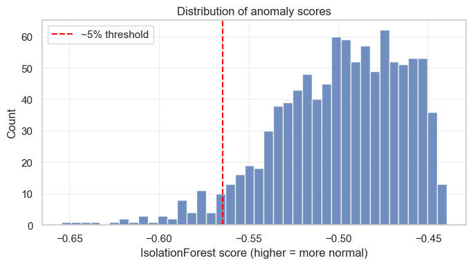

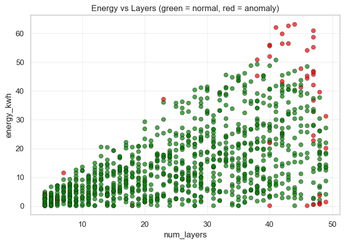

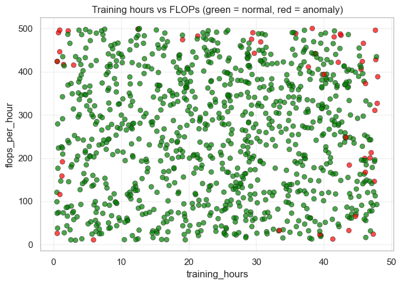

```python
# feature_cols, X_iso, iso, df_new are assumed to be already defined

# Raw anomaly scores (higher = more normal, lower = more anomalous)
iso_scores = iso.score_samples(X_iso)

# Predicted labels: 1 = inlier (normal), -1 = outlier (anomaly)
iso_labels = iso.predict(X_iso)

# Attach results back to the original dataframe
df_iso = df_new.copy()
df_iso["iso_score"] = iso_scores
df_iso["iso_label"] = iso_labels

# 2) Basic statistics: how many anomalies?
n_samples = len(df_iso)
n_anomalies = (df_iso["iso_label"] == -1).sum()
n_normals = (df_iso["iso_label"] == 1).sum()

print(f"Total samples      : {n_samples}")
print(f"Normal points (1)  : {n_normals}  ({n_normals / n_samples:.2%})")
print(f"Anomalies (-1)     : {n_anomalies} ({n_anomalies / n_samples:.2%})")

# Check score distribution summary
print("\nAnomaly score summary (higher = more normal):")
print(df_iso["iso_score"].describe())
print("\nScore percentiles:")
for p in [1, 5, 10, 25, 50, 75, 90, 95, 99]:
    val = np.percentile(iso_scores, p)
    print(f"  {p:>2}th percentile: {val:.4f}")


# 3) Inspect most anomalous samples
# Sort by score ascending (most anomalous at the top)
most_anomalous = df_iso.sort_values("iso_score", ascending=True)

print("\nTop 10 most anomalous configurations:")
cols_to_show = feature_cols + ["iso_score", "iso_label"]
print(most_anomalous[cols_to_show].head(10))

# If you want them as a separate DataFrame:
df_anomalies = most_anomalous[most_anomalous["iso_label"] == -1]


# 4) Visualizations

# 4-1) Histogram of anomaly scores
plt.figure(figsize=(7, 4))
plt.hist(iso_scores, bins=40, alpha=0.8)
plt.xlabel("IsolationForest score (higher = more normal)")
plt.ylabel("Count")
plt.title("Distribution of anomaly scores")
plt.grid(True, alpha=0.3)

# Mark the contamination-based threshold (roughly 5% quantile)
score_threshold = np.percentile(iso_scores, 5)  # because contamination=0.05
plt.axvline(score_threshold, color="red", linestyle="--", label="~5% threshold")
plt.legend()
plt.tight_layout()
plt.show()

# 4-2) Scatter plot: energy vs layers, colored by anomaly label
plt.figure(figsize=(7, 5))

colors = np.where(df_iso["iso_label"] == -1, "red", "green")

plt.scatter(
    df_iso["num_layers"],
    df_iso["energy_kwh"],
    c=colors,
    alpha=0.7,
    edgecolors="k",
    linewidths=0.5,
)

plt.xlabel("num_layers")
plt.ylabel("energy_kwh")
plt.title("Energy vs Layers (green = normal, red = anomaly)")
plt.grid(True, alpha=0.3)
plt.tight_layout()
plt.show()

# 4-3) Optional: 2D scatter (training_hours vs flops_per_hour) colored by label
plt.figure(figsize=(7, 5))

plt.scatter(
    df_iso["training_hours"],
    df_iso["flops_per_hour"],
    c=colors,
    alpha=0.7,
    edgecolors="k",
    linewidths=0.5,
)

plt.xlabel("training_hours")
plt.ylabel("flops_per_hour")
plt.title("Training hours vs FLOPs (green = normal, red = anomaly)")
plt.grid(True, alpha=0.3)
plt.tight_layout()
plt.show()
```

**Anomaly Detect Summary**

Isolation Forest classified 50 out of 1,000 configurations (about 5%) as anomalies (-1), and the remaining 950 configurations (95%) as normal (1).

The anomaly scores (iso_score) mostly lie between -0.65 and -0.44:

- Larger scores (less negative) indicate more normal configurations
- Smaller scores (more negative) indicate more anomalous configurations

Looking at the percentiles (1%, 5%, 10%, …, 99%):

- The most anomalous region is around the bottom 5–10% of scores (approximately ≤ -0.56) and points in this range are most often labeled as anomalies.

Among the top 10 most anomalous configurations, we see common patterns:

- Very large number of layers (num_layers around 40–47),
- Long training times (training_hours roughly 35–48 hours),
- High FLOPs and high energy consumption occurring together

Additionally, there are a few structurally odd cases where FLOPs are extremely high but the energy usage is unusually low; these are also flagged as anomalies because they represent inconsistent or unrealistic patterns.

## **Optimization & Recommendation**

This section extends the rule-based prompt simplification with a semantic similarity check using pre-trained sentence embeddings

The goal is: Only accept a shorter, “optimized” prompt if it is  
- (1) semantically similar enough to the original  
- (2) actually reduces the estimated energy.

1. Prompt feature computation & Rule-based prompt simplification

First, we define a helper function to compute simple complexity features from the raw prompt text:

- Token count: number of whitespace-separated tokens
- Line count: number of non-empty lines
- Complexity score: a combined score based on length and density
- Scaling factor: how much to inflate energy based on token count

This mirrors the logic used in the EcoFlux GUI

We reuse a simplified version of suggest_simpler_prompt(prompt, max_tokens=...):

- Normalize whitespace.
- Remove “filler phrases” such as:  
  - “please write in detail about”, “in as much detail as possible”,  
  - “highly detailed, multi-paragraph explanation”, etc.
- Optionally clip the prompt to a maximum number of tokens and append ... if needed.

Result: A shorter prompt that is more concise but still tries to keep the original intent.

```python
def compute_prompt_features(prompt: str):
    """
    Compute simple prompt-complexity features from raw text.
    This is a simplified version matching the EcoFlux logic.
    """
    # Token count (very rough: split on whitespace)
    tokens = prompt.split()
    token_count = len(tokens)

    # Non-empty line count
    lines = [ln for ln in prompt.splitlines() if ln.strip()]
    line_count = max(1, len(lines))  # avoid divide-by-zero

    # Average tokens per non-empty line
    avg_tokens_per_line = token_count / line_count

    # Normalised complexity score (0–1), approximate
    length_component = min(1.0, token_count / 200.0)
    density_component = min(1.0, avg_tokens_per_line / 40.0)
    complexity_score = 0.5 * (length_component + density_component)

    return token_count, line_count, complexity_score


def prompt_scaling_factor(token_count: int) -> float:
    """
    Map token count to a multiplicative scaling factor for energy.
    Same idea as in EcoFlux app.
    """
    if token_count <= 10:
        return 1.00
    elif token_count <= 20:
        return 1.02
    elif token_count <= 40:
        return 1.04
    elif token_count <= 60:
        return 1.06
    elif token_count <= 80:
        return 1.08
    elif token_count <= 100:
        return 1.10
    elif token_count <= 140:
        return 1.12
    elif token_count <= 180:
        return 1.14
    elif token_count <= 240:
        return 1.17
    else:
        return 1.20

def suggest_simpler_prompt(prompt: str, max_tokens: int = 80) -> str:
    """
    Very simple rule-based prompt simplifier.
    This is a lightweight version of your EcoFlux suggest_simpler_prompt().
    """

    cleaned = " ".join(prompt.strip().split())
    if not cleaned:
        return cleaned

    tokens = cleaned.split()
    token_count = len(tokens)

    # Do not touch very short prompts
    if token_count <= 10:
        return cleaned

    # Remove some verbose phrases (example patterns)
    filler_phrases = [
        "please write in detail about",
        "please provide a detailed explanation of",
        "in as much detail as possible",
        "you are an expert",
        "act as an expert",
        "suitable for beginners",
        "keep the explanation simple and clear",
        "highly detailed",
        "multi-paragraph explanation",
    ]

    for phrase in filler_phrases:
        cleaned = re.sub(re.escape(phrase), "", cleaned, flags=re.IGNORECASE)

    # Normalise whitespace again
    cleaned = " ".join(cleaned.split())
    tokens = cleaned.split()
    token_count = len(tokens)

    # If still too long, clip to max_tokens
    if token_count > max_tokens:
        cleaned = " ".join(tokens[:max_tokens]) + " ..."

    return cleaned
```

2. Loading a pre-trained embedding model (for cosine similarity)

```python
# Load pre-trained sentence embedding model (cached automatically in local env)
embed_model = SentenceTransformer("all-MiniLM-L6-v2")
```

3. Cosine similarity between prompts

Measure cosine similarity

The output is a scalar in [-1, 1]:

- Values close to 1.0 → very similar prompts
- Near 0 → unrelated
- Negative → opposite direction (rare for normal text)

In practice, most prompt pairs lie between 0.5 and 0.99.

```python
def semantic_similarity(prompt_a: str, prompt_b: str, model) -> float:
    """
    Compute cosine similarity between two prompts using sentence embeddings.
    Returns a scalar in [-1, 1], where 1.0 means very similar.
    """
    embeddings = model.encode([prompt_a, prompt_b])
    sim = cosine_similarity([embeddings[0]], [embeddings[1]])[0, 0]
    return float(sim)
```

4. Decision Function

Computes prompt features and total energy for both prompts:

- Original: tokens, lines, complexity, scaling, total energy
- Improved: same set of metrics

Computes cosine similarity between the original and improved prompts.

Applies the decision rule:

- (similarity >= similarity_threshold) & (improved_total_energy < original_total_energy)  
  → Use the improved prompt (used_improved = True)

Otherwise  
→ Keep the original prompt (used_improved = False)

Returns:

- final_prompt (the chosen prompt)
- info dict summarizing both variants and the similarity score

```python
def choose_prompt_with_similarity(
    original_prompt: str,
    improved_prompt: str,
    base_energy: float,
    model,
    similarity_threshold: float = 0.80,
):
    """
    Decide whether to accept the rule-based improved prompt or keep the original.

    Criteria:
    1) Semantic similarity between original and improved prompts
    2) Energy savings based on token count scaling

    Returns
    -------
    final_prompt : str
        Chosen prompt (original or improved).
    info : dict
        Diagnostic info (similarity, tokens, energies).
    """

    # 1) Semantic similarity
    sim_score = semantic_similarity(original_prompt, improved_prompt, model)

    # 2) Original prompt energy
    orig_tokens, orig_lines, orig_complexity = compute_prompt_features(original_prompt)
    orig_scale = prompt_scaling_factor(orig_tokens)
    orig_total_energy = base_energy * orig_scale

    # 3) Improved prompt energy
    imp_tokens, imp_lines, imp_complexity = compute_prompt_features(improved_prompt)
    imp_scale = prompt_scaling_factor(imp_tokens)
    imp_total_energy = base_energy * imp_scale

    # 4) Decision rule
    final_prompt = original_prompt
    used_improved = False

    if sim_score >= similarity_threshold and imp_total_energy < orig_total_energy:
        final_prompt = improved_prompt
        used_improved = True

    info = {
        "similarity": sim_score,
        "original": {
            "tokens": orig_tokens,
            "lines": orig_lines,
            "complexity": orig_complexity,
            "scale": orig_scale,
            "energy": orig_total_energy,
        },
        "improved": {
            "tokens": imp_tokens,
            "lines": imp_lines,
            "complexity": imp_complexity,
            "scale": imp_scale,
            "energy": imp_total_energy,
        },
        "used_improved": used_improved,
    }

    return final_prompt, info
```

5. Test Example

```python
# Example: long, verbose original prompt
original_prompt = """
You are an expert machine learning assistant. Please write in detail about how large language models
affect energy consumption and sustainability in modern data centers. In as much detail as possible,
explain the trade-offs between model size, training time, and hardware efficiency, and provide a
highly detailed, multi-paragraph explanation suitable for beginner readers.
"""

# Rule-based simplified candidate
improved_prompt = suggest_simpler_prompt(original_prompt, max_tokens=60)

print("=== Original prompt ===")
print(original_prompt.strip())
print("\n=== Rule-based improved prompt ===")
print(improved_prompt.strip())
```

```
=== Original prompt ===
You are an expert machine learning assistant. Please write in detail about how large language models
affect energy consumption and sustainability in modern data centers. In as much detail as possible,
explain the trade-offs between model size, training time, and hardware efficiency, and provide a
highly detailed, multi-paragraph explanation suitable for beginner readers.

=== Rule-based improved prompt ===
machine learning assistant. how large language models affect energy consumption and sustainability in modern data centers. , explain the trade-offs between model size, training time, and hardware efficiency, and provide a , suitable for beginner readers.
```

6. Threshold sensitivity experiment

```python
# Assume a base energy estimate from your regression model
base_energy = 5.0  # kWh (for testing)

final_prompt, info = choose_prompt_with_similarity(
    original_prompt=original_prompt,
    improved_prompt=improved_prompt,
    base_energy=base_energy,
    model=embed_model,
    similarity_threshold=0.80,   # you can play with this
)

info_df = pd.DataFrame(
    {
        "Variant": ["Original", "Improved"],
        "Tokens": [info["original"]["tokens"], info["improved"]["tokens"]],
        "Lines": [info["original"]["lines"], info["improved"]["lines"]],
        "Complexity": [
            round(info["original"]["complexity"], 3),
            round(info["improved"]["complexity"], 3),
        ],
        "Scale": [info["original"]["scale"], info["improved"]["scale"]],
        "Total energy (kWh)": [
            round(info["original"]["energy"], 3),
            round(info["improved"]["energy"], 3),
        ],
    }
)

print(f"Cosine similarity between prompts: {info['similarity']:.3f}")
print(f"Used improved prompt? {info['used_improved']}")
display(info_df)

for thr in [0.70, 0.80, 0.90]:
    _, info_thr = choose_prompt_with_similarity(
        original_prompt=original_prompt,
        improved_prompt=improved_prompt,
        base_energy=base_energy,
        model=embed_model,
        similarity_threshold=thr,
    )
    print(f"Threshold = {thr:.2f} | similarity = {info_thr['similarity']:.3f} | "
          f"used_improved = {info_thr['used_improved']}")
```

```
Cosine similarity between prompts: 0.896
Used improved prompt? True
```

|  | Variant | Tokens | Lines | Complexity | Scale | Total energy (kWh) |
| --- | --- | --- | --- | --- | --- | --- |
| 0 | Original | 53 | 4 | 0.298 | 1.06 | 5.3 |
| 1 | Improved | 36 | 1 | 0.540 | 1.04 | 5.2 |

```
Threshold = 0.70 | similarity = 0.896 | used_improved = True
Threshold = 0.80 | similarity = 0.896 | used_improved = True
Threshold = 0.90 | similarity = 0.896 | used_improved = False
```

Example outcome:

- For thresholds 0.70 and 0.80, the similarity is high enough → the improved prompt is accepted
- For threshold 0.90, the same similarity may fall just below the cutoff → the improved prompt is rejected

This shows that:

- A moderate threshold (e.g., 0.8) is practical: it accepts shorter prompts that are still semantically close
- A too strict threshold (e.g., 0.9) can lead to keeping the original prompt even when the difference is small

### **EcoFlux Streamlit GUI (Preparation)**

The final step of this project is to expose the trained EcoFlux models through a small web interface built with **Streamlit**.

Because Streamlit apps normally run as standalone Python scripts, the GUI logic is written as an `app.py` file in the project folder. For transparency and reproducibility, the full Streamlit code is also included below in this notebook, so the entire pipeline (data → model → GUI) can be reviewed in one place.

```python
import numpy as np
import pandas as pd
from pathlib import Path

import streamlit as st
import joblib
import matplotlib.pyplot as plt  # NEW: for baseline energy curve plot
import re  # NEW: for case-insensitive, pattern-based simplification

# --------------------------------------------------------
# EcoFlux: A Prompt-Aware Machine Learning Energy Estimator
# Streamlit GUI
#
# This version:
# - uses the trained regression models (Linear / MLP)
# - adds a prompt-complexity feature at inference time
# - recommends a shorter, lower-energy prompt
# --------------------------------------------------------

# 1. Page configuration
st.set_page_config(
    page_title="EcoFlux – Energy Estimator",
    page_icon="🌿",
    layout="wide",
)

# --------------------------------------------------------
# 2. Helper functions
# --------------------------------------------------------

@st.cache_resource
def load_models(models_dir: Path):
    """
    Load trained models from the given directory.

    Returns
    -------
    lin_model : sklearn LinearRegression
    mlp_bundle : dict with keys {"scaler", "model"}
    """
    lin_path = models_dir / "ecoflux_linear_regression.pkl"
    mlp_path = models_dir / "ecoflux_mlp_regressor.pkl"

    lin_model = joblib.load(lin_path)
    mlp_bundle = joblib.load(mlp_path)

    return lin_model, mlp_bundle

@st.cache_data
def load_energy_data(csv_path: Path) -> pd.DataFrame:
    """
    Load the synthetic energy dataset used for training the regression model.
    """
    if not csv_path.exists():
        raise FileNotFoundError(f"Dataset not found: {csv_path}")
    return pd.read_csv(csv_path)


def classify_sustainability(energy_kwh: float, baseline_kwh: float = 2.0):
    """
    Map a numeric energy value to a simple sustainability label.
    Baseline is used only for the delta, not for the thresholds.
    """
    if energy_kwh < 1.5:
        label = "🟢 Low impact"
        color = "green"
    elif energy_kwh < 3.0:
        label = "🟡 Moderate impact"
        color = "orange"
    else:
        label = "🔴 High impact"
        color = "red"

    delta = energy_kwh - baseline_kwh
    return label, color, delta

def load_iso_model(models_dir: Path):
    """
    Load the pre-trained IsolationForest model for anomaly detection.
    The model should be trained offline and saved as a .pkl file.
    """
    iso_path = models_dir / "ecoflux_iso_forest.pkl"
    iso_model = joblib.load(iso_path)
    return iso_model


def classify_anomaly(
    num_layers: float,
    training_hours: float,
    flops_per_hour: float,
    base_energy: float,
    iso_model,
    score_threshold_warn: float = -0.4,
):
    """
    Use IsolationForest to classify whether the current configuration
    is normal, unusual, or anomalous.

    Parameters
    ----------
    num_layers : float
        Model depth (layers).
    training_hours : float
        Training duration in hours.
    flops_per_hour : float
        Compute intensity in GFLOPs/hour.
    base_energy : float
        Base energy prediction (kWh) from the regression model.
        Include this only if the IsolationForest was trained with energy.
    iso_model :
        Fitted IsolationForest instance loaded from disk.
    score_threshold_warn : float
        Threshold on the anomaly score to flag "unusual" cases.

    Returns
    -------
    status_text : str
        Human-readable anomaly status.
    status_color : str
        Color name for UI (e.g., 'green', 'orange', 'red').
    score : float
        Raw anomaly score (higher = more normal, lower = more anomalous).
    """
    # IMPORTANT: The feature order and dimensionality must match
    # how you trained the IsolationForest offline.
    # Example: 4 features [num_layers, training_hours, flops_per_hour, base_energy]
    X_input_iso = np.array([[num_layers, training_hours, flops_per_hour, base_energy]])

    pred_label = iso_model.predict(X_input_iso)[0]      # 1 = normal, -1 = anomaly
    score = iso_model.score_samples(X_input_iso)[0]     # higher = more normal

    if pred_label == -1:
        status_text = "🔴 Anomalous configuration (out-of-distribution)"
        status_color = "red"
    else:
        # "Normal but unusual" vs "normal and typical"
        if score < score_threshold_warn:
            status_text = "🟡 Unusual but not critical"
            status_color = "orange"
        else:
            status_text = "🟢 Normal configuration"
            status_color = "green"

    return status_text, status_color, score

def compute_prompt_features(prompt: str):
    """
    Compute simple prompt-complexity features from raw text.

    Parameters
    ----------
    prompt : str
        User-entered prompt.

    Returns
    -------
    token_count : int
        Number of whitespace-separated tokens.
    line_count : int
        Number of non-empty lines.
    complexity_score : float
        Normalised score (roughly 0–1) based on length and density.
    """
    # Split on whitespace for a simple token approximation
    word_tokens = prompt.split()
    word_token_count = len(word_tokens)

    # newline tokens: count each '\n' as one extra token
    newline_count = prompt.count("\n")

    # Final token count
    token_count = word_token_count + newline_count

    # Count non-empty lines
    lines = [ln for ln in prompt.splitlines() if ln.strip()]
    line_count = max(1, len(lines))  # avoid divide-by-zero

    # Average tokens per non-empty line
    avg_tokens_per_line = token_count / line_count

    # Normalise into a 0–1 band (cap at typical classroom prompt sizes)
    # 0  tokens -> 0.0, 200+ tokens -> ~1.0
    length_component = min(1.0, token_count / 200.0)
    complexity_score = length_component

    # density_component = min(1.0, avg_tokens_per_line / 40.0)

    # Simple average of the two components
    # complexity_score = 0.5 * (length_component + density_component)

    return token_count, line_count, complexity_score


def suggest_simpler_prompt(prompt: str, max_tokens: int = 80):
    """
    Create a shorter version of the prompt using simple heuristics.
```

```python
    Cases:
    - Empty / whitespace-only: return as-is
    - Very short prompts (<= 10 tokens): return as-is
    - Long 'Role: / Context: / Expectation: / Final task:' prompts:
        -> return a concise, hand-crafted template preserving intent
    - Other prompts:
        -> remove filler phrases + clip to max_tokens with ellipsis
    """
    # Normalise whitespace
    cleaned = " ".join(prompt.strip().split())

    if not cleaned:
        return cleaned

    # Tokenise once for basic length decisions
    tokens = cleaned.split()
    token_count = len(tokens)

    # --- 1) Very short prompts: don't touch them ---
    if token_count <= 10:
        return cleaned

    # --- 2) Special handling for long Role/Context/Expectation style prompts ---
    has_role = "Role:" in cleaned
    has_context = "Context:" in cleaned

    if has_role and has_context and token_count > max_tokens:
        # Extract the first sentence from the Role: section, if possible
        try:
            role_start = cleaned.index("Role:")
            # From "Role:" to the end
            role_fragment = cleaned[role_start:]
            # Cut at the first period
            dot_idx = role_fragment.find(".")
            if dot_idx != -1:
                role_sentence = role_fragment[: dot_idx + 1]
            else:
                role_sentence = role_fragment
        except ValueError:
            # Fallback: if indexing fails, just keep a generic role sentence
            role_sentence = "Role: You are a sustainability-focused AI assistant."

        simplified = (
            f"{role_sentence} "
            "Context: Summarise how large language models affect energy use, carbon footprint, "
            "and sustainability. "
            "Expectation: Explain trade-offs between model performance and compute cost, and "
            "mention renewable energy, efficient hardware, and responsible AI practices. "
            "Final task: End with 3–4 bullet-point takeaways linked to modern sustainability goals."
        )

        # Clean up any extra spaces
        return " ".join(simplified.split())

    # --- 3) Generic simplification for other (non-template) prompts ---
    # Remove / compress verbose phrases (case-insensitive)
    filler_phrases = [
        "please write in detail about",
        "please provide a detailed explanation of",
        "in as much detail as possible",
        "you are an expert",
        "act as an expert",
        "suitable for beginners",
        "suitable for beginner readers",
        "keep the explanation simple and clear",
        "keep it simple and clear",
        "in simple and clear language",
        "in one sentence",
        "in a single sentence",
        "highly detailed",
        "deeply detailed",
        "multi-paragraph explanation",
        "highly structured",
    ]

    for phrase in filler_phrases:
        cleaned = re.sub(re.escape(phrase), "", cleaned, flags=re.IGNORECASE)

    # Special compression examples
    cleaned = re.sub(
        r"\btwo examples suitable for beginners\b",
        "two simple examples",
        cleaned,
        flags=re.IGNORECASE,
    )

    cleaned = re.sub(
        r"\bprovide a highly detailed, multi-paragraph explanation\b",
        "provide a clear explanation",
        cleaned,
        flags=re.IGNORECASE,
    )

    # Normalise whitespace again after removals
    cleaned = " ".join(cleaned.split())
    tokens = cleaned.split()
    token_count = len(tokens)

    # If still short enough, return as-is
    if token_count <= max_tokens:
        return cleaned

    # Otherwise clip to max_tokens and add ellipsis
    shortened = " ".join(tokens[:max_tokens]) + " ..."
    return shortened

def prompt_scaling_factor(token_count: int) -> float:
    """
    High granularity scaling: 10 buckets
    """
    if token_count <= 10:
        return 1.00
    elif token_count <= 20:
        return 1.02
    elif token_count <= 40:
        return 1.04
    elif token_count <= 60:
        return 1.06
    elif token_count <= 80:
        return 1.08
    elif token_count <= 100:
        return 1.10
    elif token_count <= 140:
        return 1.12
    elif token_count <= 180:
        return 1.14
    elif token_count <= 240:
        return 1.17
    else:
        return 1.20

def prompt_overhead_kwh(token_count: int, complexity: float) -> float:
    """
    Estimate additional energy overhead (in kWh) due to prompt length/complexity.

    Parameters
    ----------
    token_count : int
        Number of whitespace-separated tokens in the prompt.
    complexity : float
        Complexity score in [0, 1] from compute_prompt_features.

    Returns
    -------
    overhead_kwh : float
        Estimated extra energy in kWh.
    """
    # Base energy cost per token in kWh (tunable hyperparameter)
    base_per_token = 0.01  # e.g., 0.003 kWh per token

    # Complexity amplifies or shrinks overhead:
    # complexity 0.0 -> factor ~0.5, complexity 1.0 -> factor ~1.5
    complexity_factor = 1.0 + complexity

    overhead_kwh = token_count * base_per_token * complexity_factor
    return overhead_kwh

# --------------------------------------------------------
# 3. Load models
# --------------------------------------------------------

MODELS_DIR = Path("models")

try:
    lin_model, mlp_bundle = load_models(MODELS_DIR)
    mlp_scaler = mlp_bundle["scaler"]
    mlp_model = mlp_bundle["model"]
    models_loaded = True
except Exception as e:
    st.error(f" Could not load models from {MODELS_DIR}: {e}")
    models_loaded = False
    lin_model = None
    mlp_scaler = None
    mlp_model = None

# --------------------------------------------------------
# 4. Sidebar – model choice & info
# --------------------------------------------------------

st.sidebar.title("EcoFlux Settings")
st.sidebar.markdown(
    "Select which trained model EcoFlux should use for **base energy** predictions."
)

model_choice = st.sidebar.radio(
    "Choose prediction model:",
    ("Linear Regression (recommended)", "MLPRegressor (neural network)"),
)
```

```python
st.sidebar.markdown("---")
st.sidebar.markdown(
    "**About EcoFlux**  \n"
    "EcoFlux estimates the energy usage (kWh) of an ML training run based on:\n"
    "- model depth (layers)\n"
    "- training duration (hours)\n"
    "- compute intensity (GFLOPs/hour)\n"
    "- prompt length / complexity (prototype)\n\n"
    "It is an **educational tool**, not a precise carbon accounting system."
)

# --------------------------------------------------------
# 5. Main layout – title and description
# --------------------------------------------------------

st.title("🌿 EcoFlux: Machine Learning Energy Estimator")
st.caption("Making machine learning greener through transparency.")

st.markdown(
    """
EcoFlux helps you explore how **model design choices** and **prompt length**
affect estimated training energy consumption.
Enter a prompt, adjust the sliders, and see both the original energy estimate
and a recommended lower-energy prompt.
"""
)

st.markdown("---")

# Two equal-width columns: left (inputs) and right (results)
col_left, col_right = st.columns([1, 1])

# --------------------------------------------------------
# 6. Left column – prompt + numeric inputs
# --------------------------------------------------------

with col_left:
    st.subheader("Prompt and Model Configuration")

    default_prompt = (
        "Role: You are a sustainability-focused ML assistant.\n"
        "Context: Explain the trade-offs between model size and energy use.\n"
        "Expectation: Give 3 concise bullet points suitable for students."
    )

    # Initialise once
    if "prompt_input" not in st.session_state:
        st.session_state.prompt_input = default_prompt

    # Callback used by the clear button
    def clear_prompt():
        st.session_state.prompt_input = ""

    # Text area is fully controlled by session_state
    st.text_area(
        "Enter your LLM prompt here:",
        key="prompt_input",
        height=200,
        help="This is the text the LLM would receive as input.",
    )

    # Clear / eraser button – uses callback
    st.button("Clear prompt", on_click=clear_prompt)

    # For later calculations, read from session_state
    prompt_text = st.session_state.prompt_input

    num_layers = st.slider(
        "Number of layers",
        min_value=2,
        max_value=24,
        value=8,
        step=1,
        help="Approximate depth of the model.",
    )

    training_hours = st.slider(
        "Training duration (hours)",
        min_value=0.5,
        max_value=24.0,
        value=6.0,
        step=0.5,
        help="How long the model is trained.",
    )

    flops_per_hour = st.slider(
        "Compute intensity (GFLOPs/hour)",
        min_value=10.0,
        max_value=300.0,
        value=120.0,
        step=5.0,
        help="Approximate computation per hour.",
    )

    st.markdown("")
    predict_button = st.button("Predict Energy & Recommend Prompt", type="primary")

# --------------------------------------------------------
# 7. Right column – predictions, recommendation & comparison
# --------------------------------------------------------

with col_right:
    st.subheader("Energy & Sustainability")

    if not models_loaded:
        st.warning("Models are not loaded. Please check the models directory.")
    elif not predict_button:
        st.info(
            "Enter a prompt, adjust the parameters on the left, "
            "and click **Predict Energy & Recommend Prompt**."
        )
    else:
        # -------- 7.1 Base energy from numeric model --------
        X_input = np.array([[num_layers, training_hours, flops_per_hour]])

        # ✅ LinearRegression: use raw (unscaled) features
        # ✅ MLPRegressor: use scaled features (mlp_scaler)
        if model_choice.startswith("Linear"):
            base_energy_raw = lin_model.predict(X_input)[0]
            model_used = "Linear Regression"
        else:
            X_scaled = mlp_scaler.transform(X_input)
            base_energy_raw = mlp_model.predict(X_scaled)[0]
            model_used = "MLPRegressor"

        # --- NEW: enforce non-negative (or a small physical lower-bound) ---
        MIN_ENERGY = 0.1  # or use the true min from your dataset
        base_energy = float(base_energy_raw)
        base_energy = max(MIN_ENERGY, base_energy)

        # Baseline reference configuration (e.g., 8 layers, 6h, 120 GFLOPs/h)
        baseline_X = np.array([[8, 6.0, 120.0]])

        # ✅ Again: no scaling for LinearRegression
        baseline_energy = lin_model.predict(baseline_X)[0]
        baseline_energy = max(0.0, float(baseline_energy))

        # -------- 7.2 Original prompt complexity & energy --------
        orig_tokens, orig_lines, orig_complexity = compute_prompt_features(prompt_text)

        # NEW: additive overhead in kWh based on tokens & complexity
        orig_overhead = prompt_overhead_kwh(orig_tokens, orig_complexity)
        orig_total_energy = base_energy + orig_overhead

        # -------- 7.3 Recommended simpler prompt --------
        improved_prompt = suggest_simpler_prompt(prompt_text)
        imp_tokens, imp_lines, imp_complexity = compute_prompt_features(improved_prompt)

        imp_overhead = prompt_overhead_kwh(imp_tokens, imp_complexity)
        imp_total_energy = base_energy + imp_overhead

        saving_kwh = orig_total_energy - imp_total_energy

        # -------- 7.4 Sustainability classification (original prompt) --------
        label, color, delta_vs_baseline = classify_sustainability(
            orig_total_energy, baseline_energy
        )

        # Main metric for original prompt
        st.metric(
            label="Original prompt energy estimate (kWh)",
            value=f"{orig_total_energy:.2f}",
            delta=f"{delta_vs_baseline:+.2f} kWh vs baseline",
        )

        st.markdown(
            f"**Sustainability rating:** "
            f"<span style='color:{color}; font-weight:bold;'>{label}</span>",
            unsafe_allow_html=True,
        )

        st.markdown(f"*Base model used for estimation: **{model_used}***")
```

```python
 # -------- 7.4-bis Anomaly detection (IsolationForest) --------
        try:
            iso_model = load_iso_model(MODELS_DIR)

            status_text, status_color, iso_score = classify_anomaly(
                num_layers=num_layers,
                training_hours=training_hours,
                flops_per_hour=flops_per_hour,
                base_energy=base_energy,
                iso_model=iso_model,
                score_threshold_warn=-0.53,  # you can tune this
            )

            st.markdown(
                f"**Anomaly status (IsolationForest):** "
                f"<span style='color:{status_color}; font-weight:bold;'>{status_text}</span> "
                f"(score = {iso_score:.3f})",
                unsafe_allow_html=True,
            )
        except Exception as e:
            st.info(f"Could not compute anomaly status: {e}")

        # -------- 7.5 Comparison table --------
        comparison_df = pd.DataFrame(
            {
                "Variant": ["Original prompt", "Recommended prompt"],
                "Tokens": [orig_tokens, imp_tokens],
                "Lines": [orig_lines, imp_lines],
                "Complexity score (0–1)": [
                    round(orig_complexity, 3),
                    round(imp_complexity, 3),
                ],
                "Prompt overhead (kWh)": [
                    round(orig_overhead, 3),
                    round(imp_overhead, 3),
                ],
                "Total energy (kWh)": [
                    round(orig_total_energy, 3),
                    round(imp_total_energy, 3),
                ],
            }
        )

        st.markdown("#### Original vs Recommended Prompt (Energy Comparison)")
        st.dataframe(comparison_df, use_container_width=True)

        if saving_kwh > 0:
            st.success(
                f"By using the recommended prompt, EcoFlux estimates a saving of "
                f"**{saving_kwh:.2f} kWh** for this configuration."
            )
        else:
            st.info(
                "The recommended prompt is already very concise — "
                "no additional energy savings are estimated."
            )

        # -------- 7.6 Show both prompts for inspection --------
        with st.expander("🔎 View prompts"):
            col_p1, col_p2 = st.columns(2)
            with col_p1:
                st.markdown("**Original prompt**")
                st.code(prompt_text, language="markdown")
            with col_p2:
                st.markdown("**Recommended lower-energy prompt**")
                st.code(improved_prompt, language="markdown")

        st.markdown(
            """
            **Quick Tips:**

            - Shorter, clearer prompts usually reduce token count and energy overhead.
            - Keeping role/context focused and avoiding repetition helps both clarity and sustainability.
            - Model-side choices (layers, hours, FLOPs/hour) and prompt design *together*
            determine the final energy estimate.
            """
                    )
                        # -------- 7.6 Model visualisation + prompt-specific markers --------
        try:
            data_path = Path("data/energy_synthetic_structured.csv")
            df_energy = load_energy_data(data_path)

            # Common: features and actual target from synthetic dataset
            X_all = df_energy[["num_layers", "training_hours", "flops_per_hour"]]
            y_actual_all = df_energy["energy_kwh"].values

            # ----- LINEAR REGRESSION VIEW: 2D actual vs predicted -----
            if model_choice.startswith("Linear"):
                y_pred_all = lin_model.predict(X_all)

                # Create 2D figure/axis
                fig, ax = plt.subplots()

                # DATA POINTS — more visible (alpha=0.75)
                ax.scatter(
                    y_actual_all,
                    y_pred_all,
                    alpha=0.75,
                    color="#4C72B0",
                    label="Data points",
                )

                # BEST-FIT LINE (orange)
                m, b = np.polyfit(y_actual_all, y_pred_all, 1)
                x_line = np.linspace(y_actual_all.min(), y_actual_all.max(), 100)
                y_line = m * x_line + b
                ax.plot(
                    x_line,
                    y_line,
                    color="#F28E2B",
                    linewidth=2,
                    label="Linear regression best-fit line",
                )

                # Current configuration: treat base_energy as "actual-ish" x
                x_cfg = base_energy

                # ORIGINAL PROMPT (purple diamond)
                ax.scatter(
                    x_cfg,
                    orig_total_energy,
                    marker="D",
                    s=120,
                    color="#9467BD",
                    edgecolors="black",
                    linewidth=1,
                    label="Original prompt energy",
                    zorder=6,
                )

                # RECOMMENDED PROMPT (red square)
                ax.scatter(
                    x_cfg,
                    imp_total_energy,
                    marker="s",
                    s=120,
                    color="#D62728",
                    edgecolors="black",
                    linewidth=1,
                    label="Recommended prompt energy",
                    zorder=6,
                )

                # Make sure axes start at 0
                ax.set_xlim(left=0)
                ax.set_ylim(bottom=0)

                # ----- RECOMMENDED POINT DASHED GUIDES (TO AXES) -----
                ax.vlines(
                    x_cfg,
                    ymin=0,                 # from x-axis (0 on y)
                    ymax=imp_total_energy,
                    linestyles=":",
                    linewidth=1.2,
                    color="#6E6E6E",
                )
                ax.hlines(
                    imp_total_energy,
                    xmin=0,                 # from y-axis (0 on x)
                    xmax=x_cfg,
                    linestyles=":",
                    linewidth=1.2,
                    color="#6E6E6E",
                )
```

```python
                ax.set_xlabel("Actual energy (kWh)")
                ax.set_ylabel("Predicted / prompt-adjusted energy (kWh)")
                ax.set_title("Linear Regression: Actual vs Predicted Energy")
                ax.legend(loc="upper left", frameon=True)

            # ----- MLP VIEW: 3D non-linear surface over (layers, FLOPs) -----
            else:
                # Grid ranges
                layers_vals = np.linspace(
                    df_energy["num_layers"].min(),
                    df_energy["num_layers"].max(),
                    20,
                )
                flops_vals = np.linspace(
                    df_energy["flops_per_hour"].min(),
                    df_energy["flops_per_hour"].max(),
                    20,
                )
                L_grid, F_grid = np.meshgrid(layers_vals, flops_vals)

                # Build grid for prediction
                X_grid = np.column_stack([
                    L_grid.ravel(),
                    np.full_like(L_grid.ravel(), training_hours),
                    F_grid.ravel(),
                ])
                X_grid_scaled = mlp_scaler.transform(X_grid)
                Z_pred = mlp_model.predict(X_grid_scaled).reshape(L_grid.shape)

                # Slightly smaller figure
                fig = plt.figure(figsize=(5, 4))
                ax = fig.add_subplot(111, projection="3d")

                # Pull the camera back to avoid cut-off
                ax.view_init(elev=25, azim=135)

                # -------------------------------------------------------
                # 3D SURFACE — transparent + lighter (MAIN FIX)
                # -------------------------------------------------------
                ax.plot_surface(
                    L_grid,
                    F_grid,
                    Z_pred,
                    cmap="cividis",      # cleaner & lighter colormap (optional)
                    alpha=0.45,          # MUCH lighter so markers remain visible
                    linewidth=0,
                    antialiased=True,
                )

                # Scatter real synthetic points
                ax.scatter(
                    df_energy["num_layers"],
                    df_energy["flops_per_hour"],
                    df_energy["energy_kwh"],
                    color="#4C72B0",
                    alpha=0.45,
                    s=15,
                    label="Observed energy (synthetic)",
                )

                # -------------------------------------------------------
                # Current config markers — easier to see
                # -------------------------------------------------------
                ax.scatter(
                    num_layers,
                    flops_per_hour,
                    orig_total_energy,
                    marker="D",
                    s=100,                 # larger for visibility
                    color="#9467BD",
                    edgecolors="black",
                    linewidth=1,
                    label="Original prompt energy",
                    zorder=10,
                )
                ax.scatter(
                    num_layers,
                    flops_per_hour,
                    imp_total_energy,
                    marker="s",
                    s=100,
                    color="#D62728",
                    edgecolors="black",
                    linewidth=1,
                    label="Recommended prompt energy",
                    zorder=10,
                )

                # Axis padding so nothing is cropped
                ax.set_xlim(
                    df_energy["num_layers"].min() - 1,
                    df_energy["num_layers"].max() + 1,
                )
                ax.set_ylim(
                    df_energy["flops_per_hour"].min() - 20,
                    df_energy["flops_per_hour"].max() + 20,
                )

                z_min = min(
                    df_energy["energy_kwh"].min(),
                    Z_pred.min(),
                    orig_total_energy,
                    imp_total_energy,
                )
                z_max = max(
                    df_energy["energy_kwh"].max(),
                    Z_pred.max(),
                    orig_total_energy,
                    imp_total_energy,
                )
                ax.set_zlim(z_min - 0.4, z_max + 0.6)

                # Labels & title
                ax.set_xlabel("Number of layers")
                ax.set_ylabel("Compute intensity\n(GFLOPs/h)", labelpad=8)
                ax.set_zlabel("Predicted / prompt-adjusted energy (kWh)")
                ax.set_title(
                    "MLPRegressor: Non-linear Energy Surface\n"
                    f"(training_hours fixed at {training_hours:.1f} h)"
                )
                ax.legend(loc="upper left")

            # Common Streamlit rendering
            st.markdown("#### Energy Curve and Prompt-Specific Estimates")
            fig.tight_layout(pad=0.5)
            st.pyplot(fig)

        except Exception as e:
            st.info(f"Could not draw energy curve from synthetic dataset: {e}")
```

[output not shown]

[output cut: 50 more lines]

[output not shown]

**Streamlit App Preparation Summary**

```
streamlit run app.py
```